# FML FINAL EXAM

Nikitha Chigurupati

12/18/2022

#Loading the Packages

```r
library(readr)
library(dplyr)
```

```r
library(ggplot2)
library(corrplot)
library(gridExtra)
library(pROC)
library(MASS)
library(caTools)
library(rattle)
library(rpart)
library(PreProcess)
library(gmodels)
library(rpart.plot)
library(caret)
```

#Importing the Dataset into R

```r
Breast_cancer <-read.csv("C:/Users/Nikitha/Downloads/data.csv")
```

#Checking the Dimensions of the Dataset

```r
dim(Breast_cancer)
```

```
## [1] 569  33
```

#Summary of the data

```r
summary(Breast_cancer)
```

```
##        id             diagnosis          radius_mean      texture_mean
##  Min.   :     8670   Length:569         Min.   : 6.981   Min.   : 9.71
##  1st Qu.:   869218   Class :character   1st Qu.:11.700   1st Qu.:16.17
##  Median :   906024   Mode  :character   Median :13.370   Median :18.84
##  Mean   : 30371831                      Mean   :14.127   Mean   :19.29
##  3rd Qu.:  8813129                      3rd Qu.:15.780   3rd Qu.:21.80
##  Max.   :911320502                      Max.   :28.110   Max.   :39.28
##  perimeter_mean     area_mean      smoothness_mean   compactness_mean
##  Min.   : 43.79   Min.   : 143.5   Min.   :0.05263   Min.   :0.01938
##  1st Qu.: 75.17   1st Qu.: 420.3   1st Qu.:0.08637   1st Qu.:0.06492
##  Median : 86.24   Median : 551.1   Median :0.09587   Median :0.09263
##  Mean   : 91.97   Mean   : 654.9   Mean   :0.09636   Mean   :0.10434
##  3rd Qu.:104.10   3rd Qu.: 782.7   3rd Qu.:0.10530   3rd Qu.:0.13040
##  Max.   :188.50   Max.   :2501.0   Max.   :0.16340   Max.   :0.34540
##  concavity_mean    concave.points_mean symmetry_mean    fractal_dimension_mean
##  Min.   :0.00000   Min.   :0.00000     Min.   :0.1060   Min.   :0.04996
##  1st Qu.:0.02956   1st Qu.:0.02031     1st Qu.:0.1619   1st Qu.:0.05770
##  Median :0.06154   Median :0.03350     Median :0.1792   Median :0.06154
##  Mean   :0.08880   Mean   :0.04892     Mean   :0.1812   Mean   :0.06280
##  3rd Qu.:0.13070   3rd Qu.:0.07400     3rd Qu.:0.1957   3rd Qu.:0.06612
##  Max.   :0.42680   Max.   :0.20120     Max.   :0.3040   Max.   :0.09744
##    radius_se        texture_se      perimeter_se       area_se
##  Min.   :0.1115   Min.   :0.3602   Min.   : 0.757   Min.   :  6.802
##  1st Qu.:0.2324   1st Qu.:0.8339   1st Qu.: 1.606   1st Qu.: 17.850
##  Median :0.3242   Median :1.1080   Median : 2.287   Median : 24.530
##  Mean   :0.4052   Mean   :1.2169   Mean   : 2.866   Mean   : 40.337
##  3rd Qu.:0.4789   3rd Qu.:1.4740   3rd Qu.: 3.357   3rd Qu.: 45.190
##  Max.   :2.8730   Max.   :4.8850   Max.   :21.980   Max.   :542.200
##  smoothness_se      compactness_se      concavity_se     concave.points_se
##  Min.   :0.001713   Min.   :0.002252   Min.   :0.00000   Min.   :0.000000
##  1st Qu.:0.005169   1st Qu.:0.013080   1st Qu.:0.01509   1st Qu.:0.007638
##  Median :0.006380   Median :0.020450   Median :0.02589   Median :0.010930
##  Mean   :0.007041   Mean   :0.025478   Mean   :0.03189   Mean   :0.011796
##  3rd Qu.:0.008146   3rd Qu.:0.032450   3rd Qu.:0.04205   3rd Qu.:0.014710
##  Max.   :0.031130   Max.   :0.135400   Max.   :0.39600   Max.   :0.052790
##   symmetry_se       fractal_dimension_se  radius_worst   texture_worst
##  Min.   :0.007882   Min.   :0.0008948    Min.   : 7.93   Min.   :12.02
##  1st Qu.:0.015160   1st Qu.:0.0022480    1st Qu.:13.01   1st Qu.:21.08
##  Median :0.018730   Median :0.0031870    Median :14.97   Median :25.41
##  Mean   :0.020542   Mean   :0.0037949    Mean   :16.27   Mean   :25.68
```

[output cut: 8 more lines]

```
##  Max.   :251.20   Max.   :4254.0   Max.   :0.22260   Max.   :1.05800
##  concavity_worst  concave.points_worst symmetry_worst   fractal_dimension_worst
##  Min.   :0.0000   Min.   :0.00000      Min.   :0.1565   Min.   :0.05504
##  1st Qu.:0.1145   1st Qu.:0.06493      1st Qu.:0.2504   1st Qu.:0.07146
##  Median :0.2267   Median :0.09993      Median :0.2822   Median :0.08004
##  Mean   :0.2722   Mean   :0.11461      Mean   :0.2901   Mean   :0.08395
##  3rd Qu.:0.3829   3rd Qu.:0.16140      3rd Qu.:0.3179   3rd Qu.:0.09208
##  Max.   :1.2520   Max.   :0.29100      Max.   :0.6638   Max.   :0.20750
##     X
##  Mode:logical
##  NA's:569
##
##
##
##
```

#Structure of the data

```r
str(Breast_cancer)
```

```
## 'data.frame':    569 obs. of  33 variables:
##  $ id                     : int  842302 842517 84300903 84348301 84358402 843786 844359 84458202 844981 84501001 ...
##  $ diagnosis              : chr  "M" "M" "M" "M" ...
##  $ radius_mean            : num  18 20.6 19.7 11.4 20.3 ...
##  $ texture_mean           : num  10.4 17.8 21.2 20.4 14.3 ...
##  $ perimeter_mean         : num  122.8 132.9 130 77.6 135.1 ...
##  $ area_mean              : num  1001 1326 1203 386 1297 ...
##  $ smoothness_mean        : num  0.1184 0.0847 0.1096 0.1425 0.1003 ...
##  $ compactness_mean       : num  0.2776 0.0786 0.1599 0.2839 0.1328 ...
##  $ concavity_mean         : num  0.3001 0.0869 0.1974 0.2414 0.198 ...
##  $ concave.points_mean    : num  0.1471 0.0702 0.1279 0.1052 0.1043 ...
##  $ symmetry_mean          : num  0.242 0.181 0.207 0.26 0.181 ...
##  $ fractal_dimension_mean : num  0.0787 0.0567 0.06 0.0974 0.0588 ...
##  $ radius_se              : num  1.095 0.543 0.746 0.496 0.757 ...
##  $ texture_se             : num  0.905 0.734 0.787 1.156 0.781 ...
```

[output cut: 19 more lines]

#Checking for Missing Values

```r
sum(is.na(Breast_cancer))
```

```
## [1] 569
```

#Checking the missing values in each attribute

```r
colMeans(is.na(Breast_cancer))
```

```
##                      id               diagnosis             radius_mean
##                       0                       0                       0
##            texture_mean          perimeter_mean               area_mean
##                       0                       0                       0
##         smoothness_mean        compactness_mean          concavity_mean
##                       0                       0                       0
##     concave.points_mean           symmetry_mean  fractal_dimension_mean
##                       0                       0                       0
##               radius_se              texture_se            perimeter_se
##                       0                       0                       0
##                 area_se           smoothness_se          compactness_se
##                       0                       0                       0
##            concavity_se       concave.points_se             symmetry_se
##                       0                       0                       0
##    fractal_dimension_se            radius_worst           texture_worst
##                       0                       0                       0
##         perimeter_worst              area_worst        smoothness_worst
##                       0                       0                       0
##       compactness_worst         concavity_worst    concave.points_worst
##                       0                       0                       0
##          symmetry_worst fractal_dimension_worst                       X
##                       0                       0                       1
```

#Removing the Id and X (Unnecessary Attributes)

```r
Breast_cancer$id <-NULL
Breast_cancer$X<- NULL
```

#Rechecking again for Missing values

```r
sum(is.na(Breast_cancer))
```

```
## [1] 0
```

#Converting Diagnosis into Factor

```r
Breast_cancer$diagnosis <- as.factor(Breast_cancer$diagnosis)
```

#Numeric Data

```r
Breast_cancer_Num <-(Breast_cancer[,2:31])
head(Breast_cancer_Num)
```

```
##   radius_mean texture_mean perimeter_mean area_mean smoothness_mean
## 1       17.99        10.38         122.80    1001.0         0.11840
## 2       20.57        17.77         132.90    1326.0         0.08474
## 3       19.69        21.25         130.00    1203.0         0.10960
## 4       11.42        20.38          77.58     386.1         0.14250
## 5       20.29        14.34         135.10    1297.0         0.10030
## 6       12.45        15.70          82.57     477.1         0.12780
##   compactness_mean concavity_mean concave.points_mean symmetry_mean
## 1          0.27760         0.3001             0.14710        0.2419
## 2          0.07864         0.0869             0.07017        0.1812
## 3          0.15990         0.1974             0.12790        0.2069
## 4          0.28390         0.2414             0.10520        0.2597
## 5          0.13280         0.1980             0.10430        0.1809
## 6          0.17000         0.1578             0.08089        0.2087
##   fractal_dimension_mean radius_se texture_se perimeter_se area_se
```

[output cut: 34 more lines]

#Correlation of the numeric attributes of the data

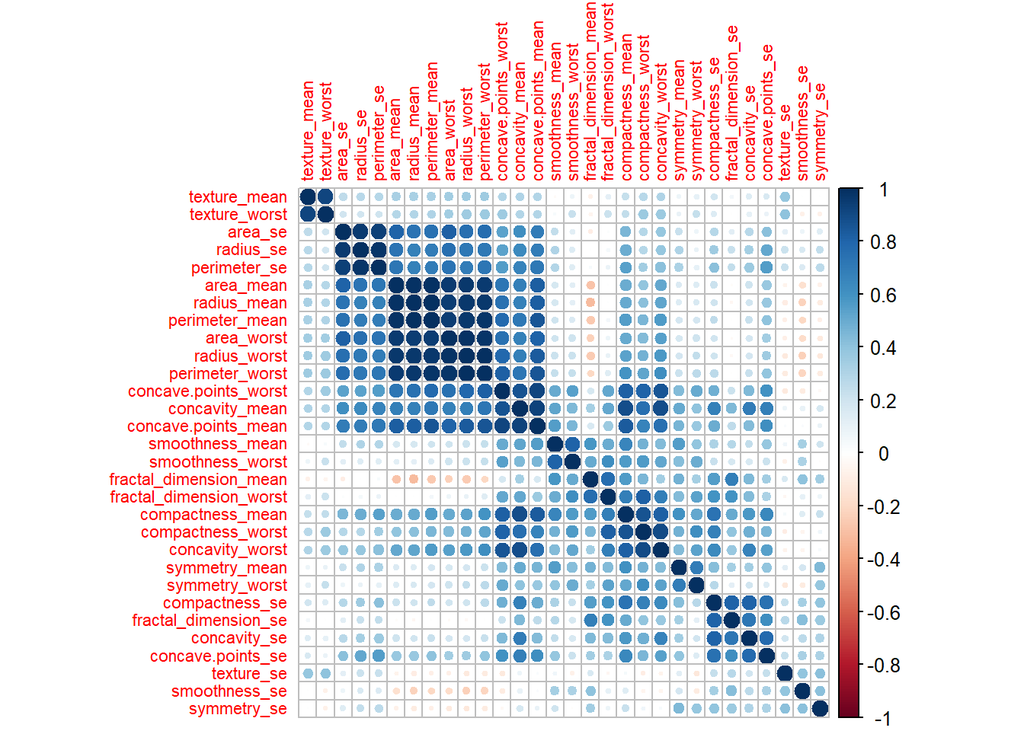

```r
Breast_cancer_Num <-cor(Breast_cancer[,2:31])
corrplot(Breast_cancer_Num, order = "hclust", tl.cex = 0.7)
```

From the above graph it is concluded that we frequently have highly connected traits that offer duplicate information. To prevent a prediction bias for the data these features include by removing highly linked features. This demonstrates the need to remember that just because a feature is useful for predicting an outcome does not mean that it is causative; rather, it may merely be linked with other causal factors when making claims about the biological or medical significance of that feature.

#Looking at the attributes that have a correlation of 0.9 or above.

```r
highlyCor <- colnames(Breast_cancer)[findCorrelation(Breast_cancer_Num, cutoff = 0.9, verbose = TRUE)]
```

```
## Compare row 7  and column  8 with corr  0.921
##   Means:  0.571 vs 0.389 so flagging column 7
## Compare row 8  and column  28 with corr  0.91
##   Means:  0.542 vs 0.377 so flagging column 8
## Compare row 23  and column  21 with corr  0.994
##   Means:  0.48 vs 0.367 so flagging column 23
## Compare row 21  and column  3 with corr  0.969
##   Means:  0.446 vs 0.359 so flagging column 21
## Compare row 3  and column  24 with corr  0.942
##   Means:  0.414 vs 0.353 so flagging column 3
## Compare row 24  and column  1 with corr  0.941
##   Means:  0.39 vs 0.349 so flagging column 24
## Compare row 1  and column  4 with corr  0.987
##   Means:  0.35 vs 0.347 so flagging column 1
## Compare row 13  and column  11 with corr  0.973
##   Means:  0.372 vs 0.346 so flagging column 13
## Compare row 11  and column  14 with corr  0.952
##   Means:  0.323 vs 0.347 so flagging column 14
## Compare row 22  and column  2 with corr  0.912
##   Means:  0.224 vs 0.357 so flagging column 2
## All correlations <= 0.9
```

#List of attributes which are highly Correlated

```r
highlyCor
```

[output not shown]

#Scatterplot

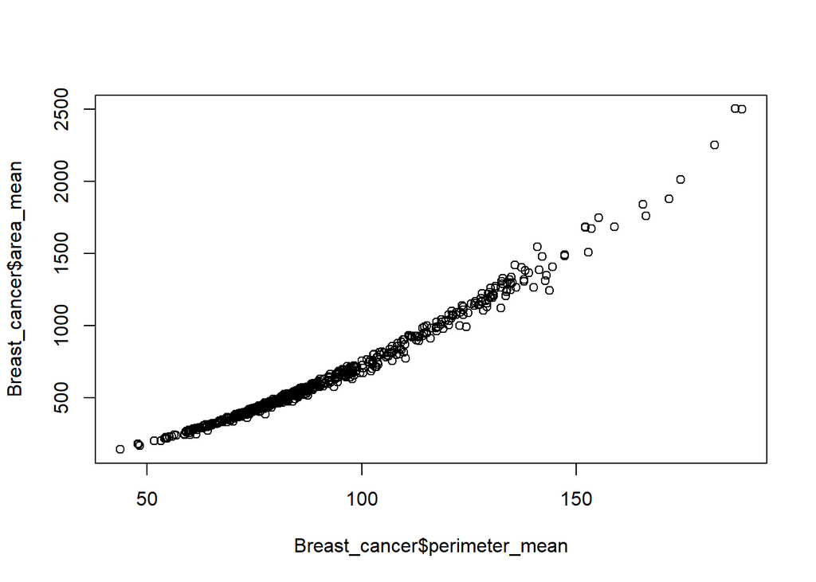

```r
plot(Breast_cancer$perimeter_mean, Breast_cancer$area_mean)
```

There is a positive relationship between the Perimeter mean and the Area mean

#Normalising the data

```r
Breast_cancer_norm <- preProcess(Breast_cancer, method = c("range"))
Breast_cancer_norm<-predict(Breast_cancer_norm, Breast_cancer)
summary(Breast_cancer_norm)
```

```
##  diagnosis  radius_mean      texture_mean    perimeter_mean     area_mean
##  B:357     Min.   :0.0000   Min.   :0.0000   Min.   :0.0000   Min.   :0.0000
##  M:212     1st Qu.:0.2233   1st Qu.:0.2185   1st Qu.:0.2168   1st Qu.:0.1174
##            Median :0.3024   Median :0.3088   Median :0.2933   Median :0.1729
##            Mean   :0.3382   Mean   :0.3240   Mean   :0.3329   Mean   :0.2169
##            3rd Qu.:0.4164   3rd Qu.:0.4089   3rd Qu.:0.4168   3rd Qu.:0.2711
##            Max.   :1.0000   Max.   :1.0000   Max.   :1.0000   Max.   :1.0000
##  smoothness_mean  compactness_mean concavity_mean    concave.points_mean
##  Min.   :0.0000   Min.   :0.0000   Min.   :0.00000   Min.   :0.0000
##  1st Qu.:0.3046   1st Qu.:0.1397   1st Qu.:0.06926   1st Qu.:0.1009
##  Median :0.3904   Median :0.2247   Median :0.14419   Median :0.1665
##  Mean   :0.3948   Mean   :0.2606   Mean   :0.20806   Mean   :0.2431
##  3rd Qu.:0.4755   3rd Qu.:0.3405   3rd Qu.:0.30623   3rd Qu.:0.3678
##  Max.   :1.0000   Max.   :1.0000   Max.   :1.00000   Max.   :1.0000
##  symmetry_mean    fractal_dimension_mean   radius_se         texture_se
##  Min.   :0.0000   Min.   :0.0000         Min.   :0.00000   Min.   :0.0000
##  1st Qu.:0.2823   1st Qu.:0.1630         1st Qu.:0.04378   1st Qu.:0.1047
##  Median :0.3697   Median :0.2439         Median :0.07702   Median :0.1653
##  Mean   :0.3796   Mean   :0.2704         Mean   :0.10635   Mean   :0.1893
##  3rd Qu.:0.4530   3rd Qu.:0.3404         3rd Qu.:0.13304   3rd Qu.:0.2462
##  Max.   :1.0000   Max.   :1.0000         Max.   :1.00000   Max.   :1.0000
##   perimeter_se        area_se        smoothness_se    compactness_se
##  Min.   :0.00000   Min.   :0.00000   Min.   :0.0000   Min.   :0.00000
##  1st Qu.:0.04000   1st Qu.:0.02064   1st Qu.:0.1175   1st Qu.:0.08132
##  Median :0.07209   Median :0.03311   Median :0.1586   Median :0.13667
##  Mean   :0.09938   Mean   :0.06264   Mean   :0.1811   Mean   :0.17444
##  3rd Qu.:0.12251   3rd Qu.:0.07170   3rd Qu.:0.2187   3rd Qu.:0.22680
##  Max.   :1.00000   Max.   :1.00000   Max.   :1.0000   Max.   :1.00000
##   concavity_se     concave.points_se  symmetry_se     fractal_dimension_se
##  Min.   :0.00000   Min.   :0.0000    Min.   :0.0000   Min.   :0.00000
##  1st Qu.:0.03811   1st Qu.:0.1447    1st Qu.:0.1024   1st Qu.:0.04675
##  Median :0.06538   Median :0.2070    Median :0.1526   Median :0.07919
##  Mean   :0.08054   Mean   :0.2235    Mean   :0.1781   Mean   :0.10019
##  3rd Qu.:0.10619   3rd Qu.:0.2787    3rd Qu.:0.2195   3rd Qu.:0.12656
##  Max.   :1.00000   Max.   :1.0000    Max.   :1.0000   Max.   :1.00000
##   radius_worst    texture_worst    perimeter_worst    area_worst
##  Min.   :0.0000   Min.   :0.0000   Min.   :0.0000   Min.   :0.00000
##  1st Qu.:0.1807   1st Qu.:0.2415   1st Qu.:0.1678   1st Qu.:0.08113
##  Median :0.2504   Median :0.3569   Median :0.2353   Median :0.12321
##  Mean   :0.2967   Mean   :0.3640   Mean   :0.2831   Mean   :0.17091
##  3rd Qu.:0.3863   3rd Qu.:0.4717   3rd Qu.:0.3735   3rd Qu.:0.22090
##  Max.   :1.0000   Max.   :1.0000   Max.   :1.0000   Max.   :1.00000
##  smoothness_worst compactness_worst concavity_worst   concave.points_worst
##  Min.   :0.0000   Min.   :0.0000    Min.   :0.00000   Min.   :0.0000
##  1st Qu.:0.3000   1st Qu.:0.1163    1st Qu.:0.09145   1st Qu.:0.2231
##  Median :0.3971   Median :0.1791    Median :0.18107   Median :0.3434
##  Mean   :0.4041   Mean   :0.2202    Mean   :0.21740   Mean   :0.3938
##  3rd Qu.:0.4942   3rd Qu.:0.3025    3rd Qu.:0.30583   3rd Qu.:0.5546
##  Max.   :1.0000   Max.   :1.0000    Max.   :1.00000   Max.   :1.0000
##  symmetry_worst   fractal_dimension_worst
##  Min.   :0.0000   Min.   :0.0000
##  1st Qu.:0.1851   1st Qu.:0.1077
##  Median :0.2478   Median :0.1640
##  Mean   :0.2633   Mean   :0.1896
##  3rd Qu.:0.3182   3rd Qu.:0.2429
##  Max.   :1.0000   Max.   :1.0000
```

#Partiting the data to Train (80%) and Test (20%).

```r
Index <- createDataPartition(Breast_cancer_norm$diagnosis, p=0.8, list = FALSE)
Train <- Breast_cancer_norm[Index,]
Test <- Breast_cancer_norm[-Index,]
```

#Building a KNN Model

```r
serach_grid <- expand.grid(k= 1:15)
KNN_Model <- train(diagnosis~., data=Breast_cancer_norm, method="knn", tuneGrid = serach_grid, preProcess= 'range')
KNN_Model
```

```
## k-Nearest Neighbors
##
## 569 samples
##  30 predictor
##   2 classes: 'B', 'M'
##
## Pre-processing: re-scaling to [0, 1] (30)
## Resampling: Bootstrapped (25 reps)
## Summary of sample sizes: 569, 569, 569, 569, 569, 569, ...
## Resampling results across tuning parameters:
##
##   k   Accuracy   Kappa
##    1  0.9524133  0.8956440
##    2  0.9505306  0.8917904
##    3  0.9527430  0.8965933
##    4  0.9564571  0.9043895
##    5  0.9594197  0.9109927
##    6  0.9582232  0.9085891
##    7  0.9614882  0.9155859
##    8  0.9621960  0.9169069
##    9  0.9620847  0.9167463
##   10  0.9609288  0.9141367
##   11  0.9632810  0.9191696
##   12  0.9615984  0.9156144
##   13  0.9626065  0.9175534
##   14  0.9612414  0.9144201
##   15  0.9620279  0.9161268
##
## Accuracy was used to select the optimal model using the largest value.
## The final value used for the model was k = 11.
```

```r
library(FNN)
Train_Predictors<-Train[,2:31]
Test_Predictors<-Test[,2:31]
Train_labels <-Train[,1]
Test_labels  <-Test[,1]

#Training a kNN Model
Predicted_Test_labels <-knn(Train_Predictors,Test_Predictors,cl=Train_labels, k=13 )
head(Predicted_Test_labels)
```

```
## [1] M M M M M B
## Levels: B M
```

```r
CrossTable(x=Test_labels, y=Predicted_Test_labels, prop.chisq= FALSE)
```

```
##
##
##    Cell Contents
## |-------------------------|
## |                       N |
## |           N / Row Total |
## |           N / Col Total |
## |         N / Table Total |
## |-------------------------|
##
##
## Total Observations in Table:  113
##
##
##              | Predicted_Test_labels
##  Test_labels |         B |         M | Row Total |
## -------------|-----------|-----------|-----------|
##            B |        70 |         1 |        71 |
##              |     0.986 |     0.014 |     0.628 |
##              |     0.986 |     0.024 |           |
##              |     0.619 |     0.009 |           |
## -------------|-----------|-----------|-----------|
##            M |         1 |        41 |        42 |
##              |     0.024 |     0.976 |     0.372 |
##              |     0.014 |     0.976 |           |
##              |     0.009 |     0.363 |           |
## -------------|-----------|-----------|-----------|
## Column Total |        71 |        42 |       113 |
##              |     0.628 |     0.372 |           |
## -------------|-----------|-----------|-----------|
##
##
```

#Confusion Matrix of KNN Model

```r
Pred_Breast_Cancer <- predict(KNN_Model, Test)
confusionMatrix(Pred_Breast_Cancer, Test$diagnosis)
```

```
## Confusion Matrix and Statistics
##
##           Reference
## Prediction  B  M
##          B 71  1
##          M  0 41
##
##                Accuracy : 0.9912
##                  95% CI : (0.9517, 0.9998)
##     No Information Rate : 0.6283
##     P-Value [Acc > NIR] : <2e-16
##
##                   Kappa : 0.981
##
##  Mcnemar's Test P-Value : 1
##
##             Sensitivity : 1.0000
##             Specificity : 0.9762
##          Pos Pred Value : 0.9861
##          Neg Pred Value : 1.0000
##              Prevalence : 0.6283
##          Detection Rate : 0.6283
##    Detection Prevalence : 0.6372
##       Balanced Accuracy : 0.9881
##
##        'Positive' Class : B
##
```

#Building the Decision Tree Model

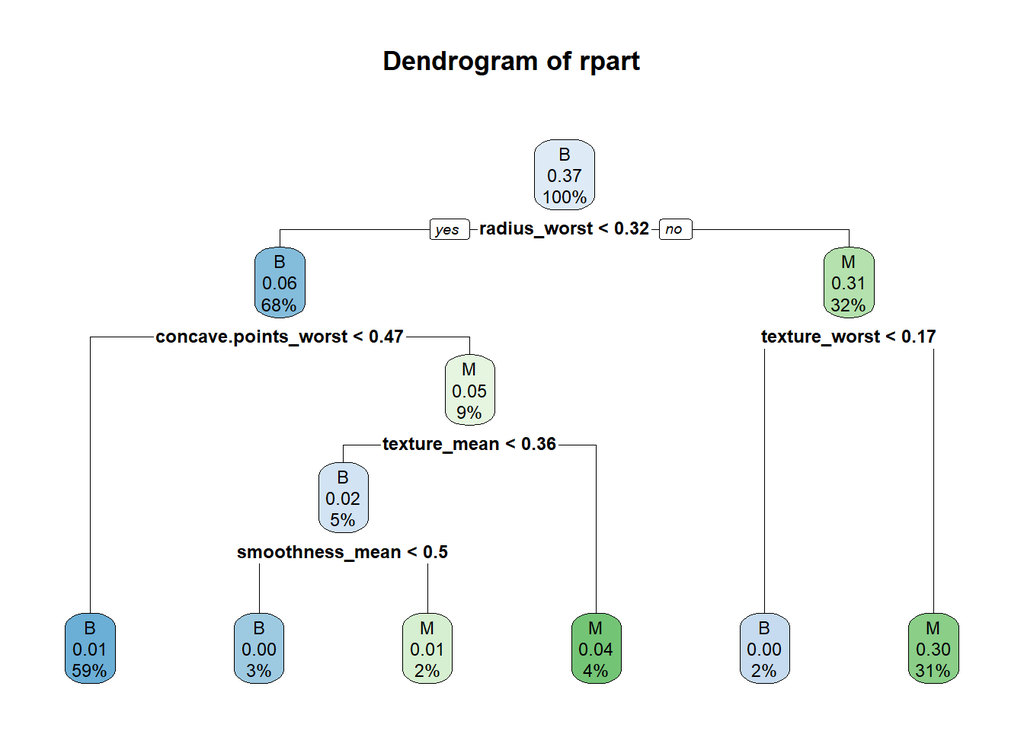

```r
set.seed(123)
library(rpart.plot)
Decision_Tree_Model<- rpart(diagnosis ~ .,data=Train,method = 'class')
rpart.plot(Decision_Tree_Model, extra = 110, main="Dendrogram of rpart")
```

#Predicting the probability

```r
Prob_Decision_Tree <- predict(Decision_Tree_Model, newdata = Test, type = "prob")
```

#Receiving Operating Characteritics Curve

```r
roc(Test$diagnosis,Prob_Decision_Tree[,2])
```

```
##
## Call:
## roc.default(response = Test$diagnosis, predictor = Prob_Decision_Tree[,     2])
##
## Data: Prob_Decision_Tree[, 2] in 71 controls (Test$diagnosis B) < 42 cases (Test$diagnosis M).
## Area under the curve: 0.9705
```

#Building the Confusion Matrix

```r
set.seed(123)
Class_Decision_Tree <- predict(Decision_Tree_Model, newdata = Test, type = "class")
confusionMatrix(as.factor(Class_Decision_Tree),as.factor(Test$diagnosis))
```

```
## Confusion Matrix and Statistics
##
##           Reference
## Prediction  B  M
##          B 66  3
##          M  5 39
##
##                Accuracy : 0.9292
##                  95% CI : (0.8653, 0.9689)
##     No Information Rate : 0.6283
##     P-Value [Acc > NIR] : 1.372e-13
##
##                   Kappa : 0.8499
##
##  Mcnemar's Test P-Value : 0.7237
##
##             Sensitivity : 0.9296
##             Specificity : 0.9286
##          Pos Pred Value : 0.9565
##          Neg Pred Value : 0.8864
##              Prevalence : 0.6283
##          Detection Rate : 0.5841
##    Detection Prevalence : 0.6106
##       Balanced Accuracy : 0.9291
##
##        'Positive' Class : B
##
```

From the above model, the KNN Model is the optimal model for this dataset. It is the best model to use as it has higher accuracy than the Decision Tree Model. Hence, KNN Model is the right and optimal Model to use.